# Tema8.1

jcantero

28/10/2020

Carga el conjunto de datos de la carpeta data llamado grades.txt en R y responde a las siguientes preguntas

```r
df = read.table("../data/grades.txt")
head(df)
```

```
##       estudio     nota
## 1  Industrial 4.811598
## 2  Telematica 3.825744
## 3  Telematica 3.518318
## 4       Mates 0.000000
## 5  Telematica 5.879675
## 6 Informatica 3.554049
```

```r
str(df)
```

```
## 'data.frame':    200 obs. of  2 variables:
##  $ estudio: Factor w/ 4 levels "Industrial","Informatica",..: 1 4 4 3 4 2 3 2 4 4 ...
##  $ nota   : num  4.81 3.83 3.52 0 5.88 ...
```

Preguntas de esta tarea

1. Calcula la media, la mediana y la moda redondeada a dos cifras decimales de las notas numéricas de los exámenes tanto de forma conjunta como por estudio universitario. ¿En qué grupo observamos la nota más alta? ¿Qué grupo está por encima de la media de estudiantes?

Todas las notas:

```r
notas = df$nota;
media = round(mean(notas), 2) # mean
mediana = round(median(notas), 2)
moda = as.numeric(names(which(table(notas)==max(table(notas))))) #La moda
```

La medias es 3.87, la mediana es 3.5 y la moda es 0

Notas de Informaticos:

```r
notas = round(df[df$estudio == 'Informatica',]$nota, 2)
media = round(mean(notas), 2) # mean
mediana = round(median(notas), 2)
moda = as.numeric(names(which(table(notas)==max(table(notas)))))  #La moda
```

La medias es 3.95, la mediana es 3.48 y la moda es 3.32, 3.48, 5.17

Notas de Matematicos:

```r
notas = round(df[df$estudio == 'Mates',]$nota, 2)
media = round(mean(notas), 2) # mean
mediana = round(median(notas), 2)
moda = as.numeric(names(which(table(notas)==max(table(notas)))))  #La moda
```

La medias es 4.22, la mediana es 4.1 y la moda es 5.75

Notas de Telematicos:

```r
notas = round(df[df$estudio == 'Telematica',]$nota, 2)
media = round(mean(notas), 2) # mean
mediana = round(median(notas), 2)
moda = as.numeric(names(which(table(notas)==max(table(notas)))))  #La moda
```

La medias es 3.7, la mediana es 3.41 y la moda es 3.41

Notas de Industriales:

```r
notas = round(df[df$estudio == 'Industrial',]$nota, 2)
media = round(mean(notas), 2) # mean
mediana = round(median(notas), 2)
moda = as.numeric(names(which(table(notas)==max(table(notas)))))  #La moda
```

La medias es 3.58, la mediana es 3.44 y la moda es 0, 2.84

Por encima de la media estan los informaticos y los Matematicos.

2. ¿En qué grupo observamos más variación de notas? Justifica tu respuesta

Informaticos:

```r
notas = round(df[df$estudio == 'Informatica',]$nota, 2)
media = round(mean(notas), 2) # mean
variacion = (sd(notas)/media) * 100
```

Variacion es de 38.9301775%

Matematicos:

```r
notas = round(df[df$estudio == 'Mates',]$nota, 2)
media = round(mean(notas), 2) # mean
variacion = (sd(notas)/media) * 100
```

Variacion es de 52.0258975%

Telematicos:

```r
notas = round(df[df$estudio == 'Telematica',]$nota, 2)
media = round(mean(notas), 2) # mean
variacion = (sd(notas)/media) * 100
```

Variacion es de 51.6004103%

Industriales:

```r
notas = round(df[df$estudio == 'Industrial',]$nota, 2)
media = round(mean(notas), 2) # mean
variacion = (sd(notas)/media) * 100
```

Variacion es de 56.161204%

3. ¿Hay mucha diferencia entre el grupo que has respondido en el ejercicio 1 y en el ejercicio 2? Intenta dar una explicación objetiva del suceso

4. Dibuja en un único gráfico los cuatro diagramas de caja, uno para cada grupo. Añade así mismo la nota media, pon nombre, título y color al gráfico para documentar el gráfico correctamente.

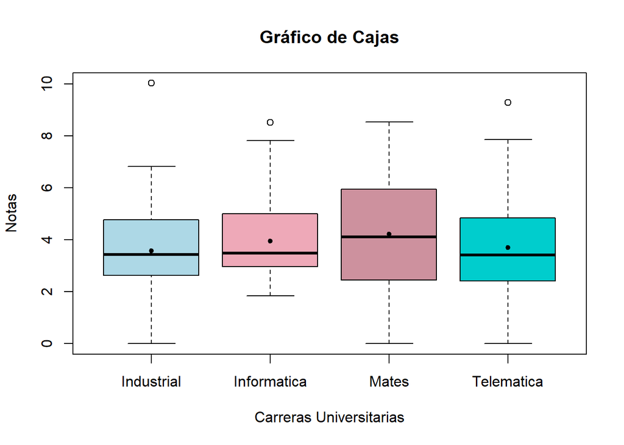

```r
boxplot(
  nota~estudio,
  data = df,
  col = c("lightblue","pink2","pink3","cyan3" ),
  xlab = "Carreras Universitarias",
  ylab = "Notas",
  main = "Gráfico de Cajas")

medias = aggregate(nota~estudio, data = df, FUN = mean)
points(medias, col = "black", pch = 20)
```

5. ¿Observas algunos valores atípicos en el boxplot anterior? ¿A qué grupo pertence?

Si existe varios outliers, y los infomaticos tiene pocas notas por deajo del primer percentil.

7. Indica a partir del boxplot anterior en qué grupo observamos más variedad de notas.

En el de mates ya que su caja y bigotes son mas grandes.

8. En base a todo lo anterior, ¿puedes afirmar de forma estadística que el examen de carrera ha ido mejor en algún estudio que en los demás?